# Final Project

Veronica Williamson

2024-11-07

# The Effects of Coral Diversity on *Acropora palmata* Growth in a Land Based Nursery

Null Hypothesis: There is no significant difference in area growth among the 6 treatments over the 12-week period.  
Alternative Hypothesis: At least one of the 6 treatments results in a significant difference in area growth over the 12-week period.

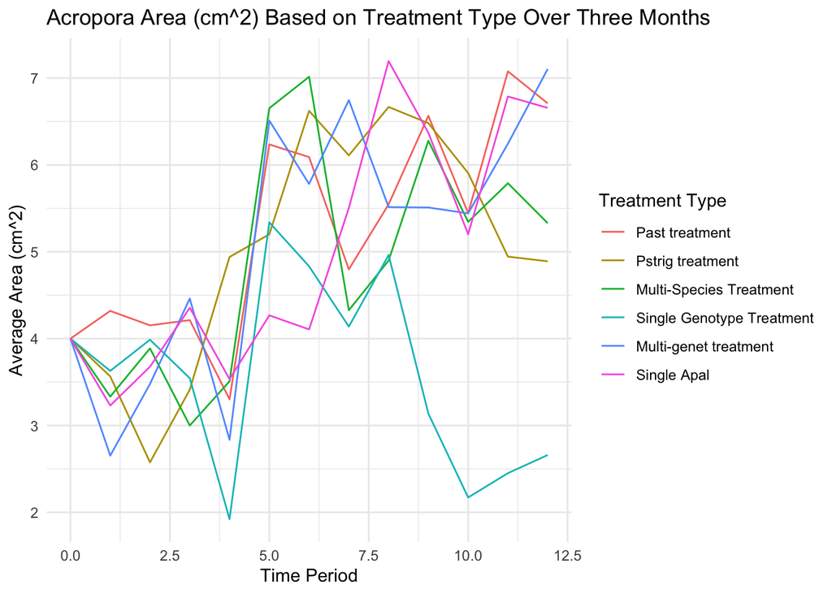

## Analysis

A linear model was run to examine the relationship between coral growth (Area_cmsq) and two key factors: TreatmentID and Time_period (1-12). The formula below evaluates the main effects of each factor and the interaction effect between TreatmentID and Time_period. This allows us to see whether the effect of treatment on coral growth changes over time.

```r
lm_model <- lm(Area_cmsq ~ TreatmentID * Time_period, data = og_df)
```

## Results

Residual standard error: 2.244 on 456 degrees of freedom  
Multiple R-squared: 0.1807  
Adjusted R-squared: 0.1609  
F-statistic: 9.142 on 11 and 456 DF  
p-value: 7.562e-15  
The results suggest that treatment effects alone were not significant, but that certain time periods and specific treatment-time interactions ( Treatment 4: Single Genotype Treatment at later time periods) had a significant effect on coral growth.

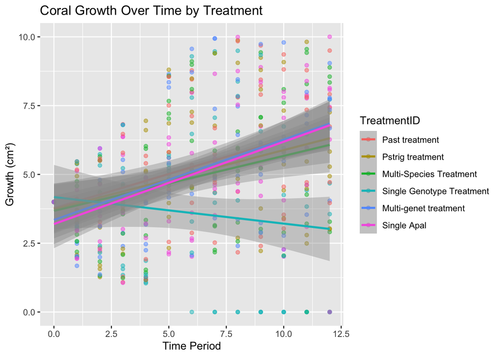